# Exploratory Data Analysis of Prosper Loan Data

# Plot 1.

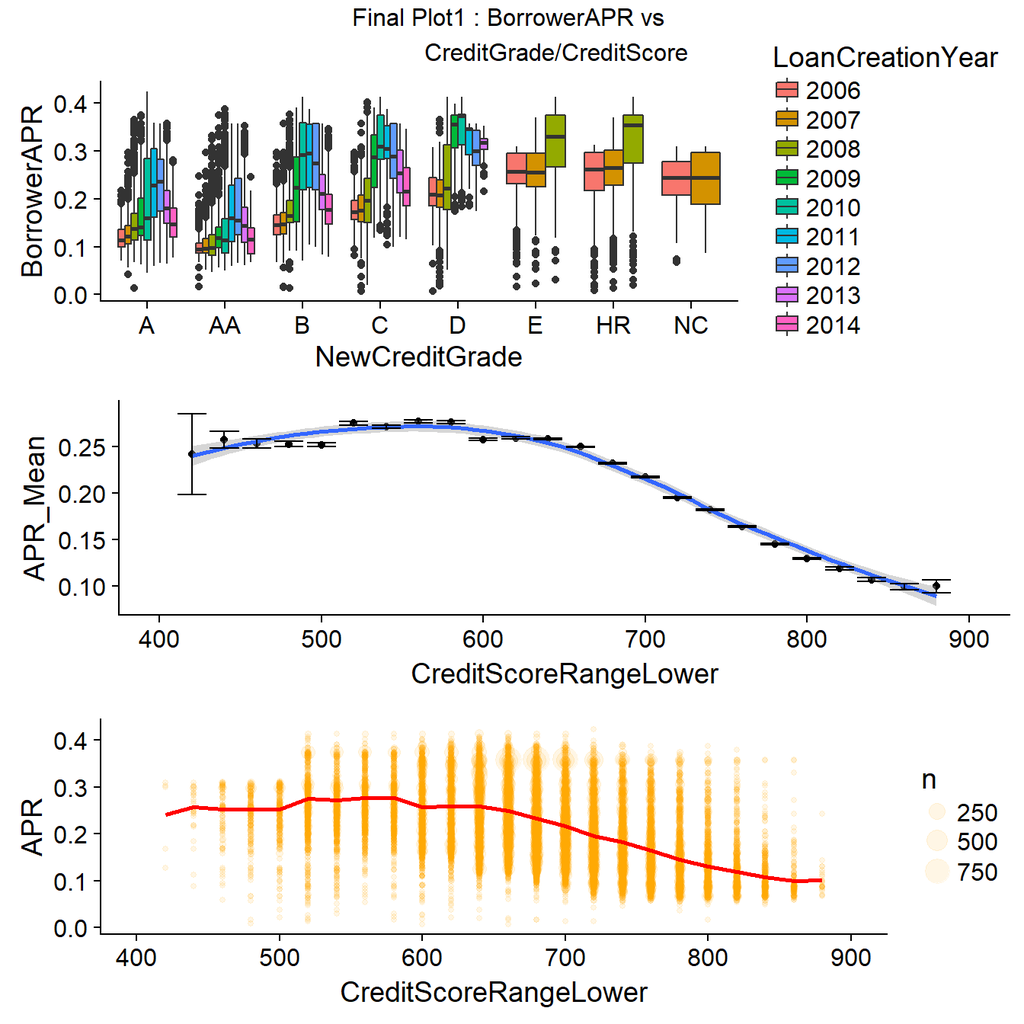

These plots show that the BorrowerAPR depends on the CreditScore/CreditGrade.

The boxplot line in the middle is the median value. So one can see that the Borrower APR becomes higher as the CreditGrade worsens, but there are outliers (indicated by the points) which lie beyond the whiskers (above 95% C.L.). So, some people with low credit still have low APR’s and there is some overlap of APR’s in each category. For the overlaps,factors other than the CreditGrade contributed to lowering the APR. Also, interestingly, the APR’s are broader as they rise for different years, which means that there is more variability in the APR in the years after 2008. It could be because more factors were considered in deciding the APR, or there was a change in algorithm, which could have caused this trend. One can see that among the different years, 2006 had the minimum APR’s, and it increased until 2009, 2010. APR’s then show a decreasing trend from 2011-2014. This happens for all creditgrade categories, except maybe HR and NC.

The second and third sub-plots esentially show the variation of the APR mean. The second sub-plot shows the mean APR and the standard error on the mean, calculated as mean/sqrt(n-1), where n is the number of events in each bin. The third sub-plot shows the distribution of the plots with the mean superimposed. One can see from the sizes of the points how the APR’s are distributed.